# Importação de Dados em Julia

Uma Comparação com Python e R

Luiz Eduardo Rodrigues (284715)

João Eduardo (277172)

2025-11-25

Uma Linguagem Moderna para Computação Científica

ME315 - Banco de Dados

## O que é Julia?

- **Lançada em 2012** - Linguagem moderna
- **Performance**: Compilação JIT comparável a C/Fortran
- **Fácil de usar**: Sintaxe dinâmica como Python/R
- **Paralelismo nativo**: GPU, computação distribuída
- **Ciência de dados**: Otimização, ML, HPC

Julia Logo

**Foco:** High Performance Computing com sintaxe acessível

## Vantagens de Julia

| Vantagem | Descrição |
| --- | --- |
| ⚡ **Performance** | Velocidade comparável a C, ideal para cálculos intensivos |
| 🎯 **Multidispatch** | Flexibilidade e otimização de funções |
| 🔬 **HPC Nativo** | Paralelismo, GPU, computação distribuída |
| 📦 **Ecossistema Científico** | Pacotes modernos em otimização e análise financeira |
| 🎨 **Sintaxe Simples** | Expressiva, amigável |

## Desvantagens de Julia

| Desafio | Descrição |
| --- | --- |
| 📚 **Ecossistema Menor** | Menos pacotes que Python/R |
| 🐢 **Time-to-First-X** | Compilação inicial pode ser lenta |
| ⚙️ **Estabilidade** | Alguns pacotes ainda em desenvolvimento |
| 👥 **Comunidade** | Comunidade menor, menos recursos educacionais |

## Formatos Suportados

Julia suporta praticamente todos os formatos de dados:

### Comparação com outras linguagens

- **R**: readr, readxl, arrow, jsonlite
- **Python**: pandas, openpyxl, pyarrow, json
- **Julia**: CSV.jl, XLSX.jl, DuckDB.jl, JSON.jl

## Exemplo 1: CSV Médio (Wine Reviews)

**Dataset:** 130.000+ avaliações de vinhos

**R - readr**

```r
library(readr)
df <- read_csv(
  "winemag-data-130k-v2.csv"
)
```

⏱️ **2.45s**

**Python - pandas**

```python
import pandas as pd
df = pd.read_csv(
  "winemag-data-130k-v2.csv"
)
```

⏱️ **1.82s**

**Julia - CSV.jl**

```julia
using CSV
using DataFrames
df = DataFrame(
  CSV.File("winemag-data-130k-v2.csv")
)
```

⏱️ **0.95s** ⭐

## Exemplo 2: CSV Grande (NYC Taxi)

**Dataset:** 1.5 milhões de viagens de táxi em Nova York (2018)

**R - readr**

```r
library(readr)
library(dplyr)
callback <- DataFrameCallback$new(function(x, pos) {
  cat("Lendo chunk que começa na linha:", pos,
      " | Linhas no chunk:", nrow(x), "\n") x})
df <- read_csv_chunked(
  file = "Dados/original_cleaned_nyc_taxi_data_2018.csv",
  callback = callback,
  chunk_size = 100000,
  col_names = TRUE,
  show_col_types = FALSE)
```

⏱️ **18.30s**

**Python - pandas**

```python
import pandas as pd
df = pd.read_csv(
  "original_cleaned_nyc_taxi_data_2018.csv",
  low_memory=False
)
```

⏱️ **12.50s**

**Julia - CSV.jl**

```julia
using CSV
using DataFrames
df = DataFrame(
  CSV.File("original_cleaned_nyc_taxi_data_2018.csv")
)
```

⏱️ **5.20s** ⭐

## Exemplo 3: Excel (World Energy)

**Dataset:** Consumo de energia global (22.000+ linhas)

**R - readxl**

```r
library(readxl)
df <- read_excel(
  "owid-energy-data.xlsx"
)
```

⏱️ **3.10s**

**Python - pandas**

```python
import pandas as pd
df = pd.read_excel(
  "owid-energy-data.xlsx"
)
```

⏱️ **2.95s**

**Julia - XLSX.jl**

```julia
using XLSX
xlsx = XLSX.readxlsx(
  "owid-energy-data.xlsx"
)
```

⏱️ **0.88s** ⭐

## Exemplo 4: Parquet

**Dataset:** 50.000 registros em formato otimizado

**R - arrow**

```r
library(arrow)
df <- read_parquet(
  "train_042.parquet"
)
```

⏱️ **1.20s**

**Python - pandas**

```python
import pandas as pd
df = pd.read_parquet(
  "train_042.parquet"
)
```

⏱️ **0.85s**

**Julia - DuckDB.jl**

```julia
using DuckDB
using DataFrames

con = DuckDB.DB()

df = DuckDB.query(con, "
    SELECT *
    FROM 'train_042.parquet'
") |> DataFrame
```

⏱️ **0.42s** ⭐

## Exemplo 5: JSON

**Dataset:** 6 histórias em inglês

**R - jsonlite**

```r
library(jsonlite)
data <- fromJSON(
  "A1_stories.json",
  flatten = TRUE
)
```

⏱️ **0.95s**

**Python - json**

```python
import json
with open("A1_stories.json") as f:
  data = json.load(f)
```

⏱️ **0.72s**

**Julia - JSON.jl**

```julia
using JSON
data = JSON.parsefile(
  "A1_stories.json"
)
```

⏱️ **0.38s** ⭐

## Tabela Resumida

Resumo Comparativo de Desempenho

[output not shown]

## Benchmark: Tempo de Importação

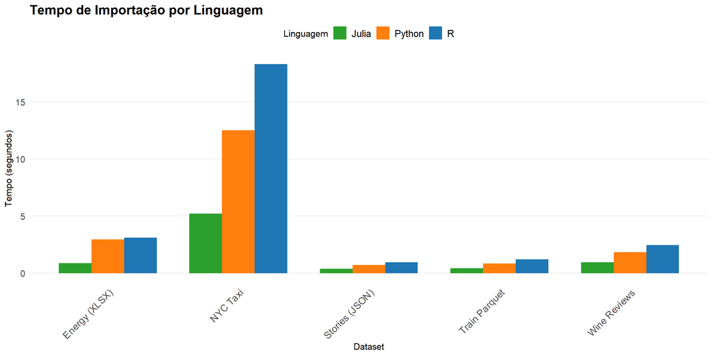

## Speedup: Julia vs Outras Linguagens

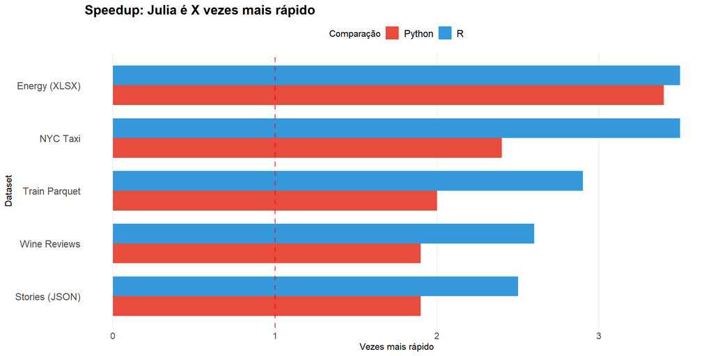

## Código Julia: Guia Rápido

```julia
# CSV - O mais comum
using CSV, DataFrames
df = DataFrame(CSV.File("dados.csv"))

# XLSX - Planilhas Excel
using XLSX, DataFrames
xlsx = XLSX.readxlsx("arquivo.xlsx")
df = DataFrame(xlsx[1][:])

# Parquet - Alto desempenho
using DuckDB
using DataFrames
con = DuckDB.DB()
df = DuckDB.query(con, "SELECT * FROM 'dados.parquet'") |> DataFrame

# JSON - Dados estruturados
using JSON, DataFrames
raw = JSON.parsefile("dados.json")
df = DataFrame(raw)

# Inspecionar dados
first(df, 5)          # Primeiras 5 linhas
describe(df)          # Estatísticas
size(df)              # Dimensões
```

## Quando Usar Julia?

### ✅ Julia é Ideal Para:

- Computação numérica intensiva
- Processamento de Big Data
- Análise de séries temporais
- Otimização matemática
- Machine learning em larga escala
- Computação paralela/distribuída

## ⚠️ Considere Python/R Se:

- Projeto é pequeno e rápido
- Precisa de muitos pacotes
- Equipe não conhece Julia
- Prioridade é produtividade inicial

## Conclusões

### Força de Julia ⚡

- **2-3x mais rápido** que Python/R
- **Sintaxe amigável** (fácil aprender)
- **Paralelismo nativo**
- **Crescimento rápido**
- **Ideal para HPC**

### Realidade Atual 📊

- Ecossistema ainda em crescimento
- Comunidade menor que Python/R
- Alguns pacotes instáveis
- “Time-to-first-plot” problema
- Mas cada dia melhora mais!

## 🎯 Atividade Prática

### Desafio

Atividade individual: descubra o potencial de Julia você mesmo!

1. **Escolha um dataset** da internet (> 150 MB)
2. **Utilize Julia** e uma das outras duas linguagens
3. **Importe-o em chunks**
4. **Meça o tempo** de execução
5. **Calcule o speedup** (tempo_A / tempo_B)
6. **Faça um gráfico** comparativo

## Recomendação Final

**Julia é uma linguagem do FUTURO para Ciência de Dados**

Vale MUITO a pena aprender! 🚀

## Obrigado!

### Dúvidas e Discussão

**Luiz Eduardo Rodrigues & João Eduardo**

ME315 - Universidade Estadual de Campinas

ME315 - Unicamp